**All analysis and interpretation of the supplied raw data represents the view of the student only and is not representative of the views of the WA Department of Biodiversity, Conservation and Attractions.**

```r
if (!require("lme4")) install.packages("lme4")
if (!require("lmerTest")) install.packages("lmerTest")
if (!require("performance")) install.packages("performance")
if (!require("emmeans")) install.packages("emmeans")
if (!require("see")) install.packages("see")
if (!require("patchwork")) install.packages("patchwork")
if (!require("AER")) install.packages("AER")
if (!require("correlation")) install.packages("correlation")
if (!require("DHARMa")) install.packages("DHARMa")
if (!require("ggplot2")) install.packages("ggplot2")
if (!require("geosphere")) install.packages("geosphere")
if (!require("GGally")) install.packages("GGally")
if (!require("ggpubr")) install.packages("ggpubr")
if (!require("MASS")) install.packages("MASS")
if (!require("reshape2")) install.packages("reshape2")
if (!require("mgcv")) install.packages("mgcv")
if (!require("sjPlot")) install.packages("sjPlot")
if (!require("splines")) install.packages("splines")
if (!require("MuMIn")) install.packages("MuMIn")
if (!require("datawizard")) install.packages("datawizard")
if (!require("RLRsim")) install.packages("RLRsim")

library(RLRsim)

library(datawizard)
library(MuMIn)
library(grid)
require(tidyverse)
require(lme4)
require(lmerTest)
require(performance)
require(emmeans)
require(see)
library(patchwork)
library(AER)
library(correlation)
library(DHARMa)
library(ggplot2)
library(geosphere)
library(GGally)
library(ggpubr)
library(MASS)
library(reshape2)
library(mgcv)
library(sjPlot)
library(splines)
library(tidyverse)
library(MuMIn)

# adjust the plot size

options(
    repr.plot.width = 10,
    repr.plot.height = 8,
    # remove warnings
    warn = -1
)
```

[output not shown]

[output cut: 42 more lines]

[output not shown]

# Introduction

This report investigates coral reef health and resilience patterns using a comprehensive dataset that captures various ecological metrics and environmental indicators. The analysis focuses on understanding the relationships between coral cover and several key factors including macroalgae presence, sand cover, maximum degree heating week, distance from boat ramps, and management zones.

Coral reef health not only affects marine biodiversity but also impacts ecosystem services, coastal protection, and overall reef resilience. By analysing these relationships, we aim to identify potential patterns and factors that contribute to coral cover changes, which could help in developing more effective conservation measures and management strategies.

This report will investigate the following questions:

1. How coral health has changed over time?
2. How coral health varies between sites?
3. Whether there are any relationships between coral health and potential disturbances and covariate data that are available such as measures of human and climate impacts?

Through statistical analysis and visualisation, we examine these questions and provide insights that can inform conservation and management decisions for Nangiloo Reserve in Western Australia.

# Data

The data used in this report is from the Nangiloo Reserve in Western Australia. The data is a combination of ecological metrics and environmental indicators, provided by the Department of Biodiversity, Conservation and Attractions (DBCA).

The data includes the following variables:

- **Survey** (character): Unique reference number for data collections
- **Year** (numeric): Year of data collection within marine reserve
- **Date** (date): Date of data collection
- **Sector** (factor): Marine reserve sector where data was collected
- **Zone** (factor): Management zone within marine reserve
- **Site** (factor): Location of data collection
- **Replicate** (character): Replicate observations of coral cover
- **Group** (character): Hard coral cover data
- **Genera** (character): Specific coral type (Acropora spp.)
- **y** (numeric): Number of points identified as coral within image series
- **n** (numeric): Total number of points in image series
- **macroalgae** (numeric): Points identified as macroalgae
- **sand** (numeric): Points identified as sand
- **mdhw** (numeric): Maximum degree heating week value

Two files are provided:

- **data_CONFIDENTIAL.csv**: The main data file containing the ecological metrics and environmental indicators.
- **lat_long.csv**: A file containing the latitude and longitude of the sites where data was collected.

The files are read in R using the following code:

```r
df <- read_csv("Send_data_2025/data_CONFIDENTIAL.csv")
lat_data <- read_csv("Send_data_2025/lat_long.csv")
```

# Data Preprocessing

The following section will preprocess the data to make it ready for analysis.

**Distance to boat ramps**

First we calculate the distances between each sampling site and the nearest boat ramp. This is important for understanding human accessibility and potential anthropogenic impacts on coral reefs.

First, we define the coordinates (longitude, latitude) of three major boat ramps in the region:

- Bundegi boat ramp
- Tantabiddi boat ramp
- Exmouth boat ramp

Using the Haversine formula (which calculates great-circle distances between points on a sphere), we compute the distance in kilometers from each sampling site to each boat ramp. The Haversine formula accounts for the Earth's curvature, providing accurate distances.

We then determine the minimum distance to any boat ramp for each site, as this represents the easiest access point. This metric can be used to analyze whether coral health correlates with accessibility to human activities like fishing, tourism, and recreational boating.

Finally, we keep only the essential columns: site identifier, minimum distance to boat ramps, and the site's coordinates.

```r
boat_ramps <- list(
  bundegi = c(114.17355436750879, -21.83101450829678),
  tantabiddi = c(113.97813636751044, -21.912434149366778),
  exmouth = c(114.14141631734854, -21.955422203417424)
)

# Calculate distances to each boat ramp
lat_data$Dist_to_Bundegi_km <- round(distHaversine(
  cbind(lat_data$Longitude, lat_data$Latitude),
  boat_ramps$bundegi
) / 1000, 2)

lat_data$Dist_to_Tantabiddi_km <- round(distHaversine(
  cbind(lat_data$Longitude, lat_data$Latitude),
  boat_ramps$tantabiddi
) / 1000, 2)

lat_data$Dist_to_Exmouth_km <- round(distHaversine(
  cbind(lat_data$Longitude, lat_data$Latitude),
  boat_ramps$exmouth
) / 1000, 2)

# Calculate minimum distance
lat_data$Min_Distance_km <- pmin(
  lat_data$Dist_to_Bundegi_km,
  lat_data$Dist_to_Tantabiddi_km,
  lat_data$Dist_to_Exmouth_km,
  na.rm = TRUE
)

# Keep only necessary columns
lat_data <- lat_data[, c("Site", "Min_Distance_km", "Latitude", "Longitude")]
```

Next, we add the latitude and longitude from the lat_data file to the main data file. This is important for spatial analysis and visualisation.

```r
# add lat and long to the data
df <- df %>%
  left_join(lat_data, by = "Site")
```

**Zone classifications**

Then we standardise and simplify the zone classifications in the dataset to create a more consistent and manageable categorisation system. This is important for analysing and comparing data across different marine protected areas and management zones.

In the original data, the zone is classified as "[zone] - [name of site]" (e.g. "Sanctuary Zone - Winderabandi"), we want to standardise this to:

- Sanctuary Zone
- Management Area
- Conservation Area
- Recreation Zone

The `grepl()` function is used to search for these keywords within the existing zone names, and when a match is found, the zone is reclassified into one of these four standardised categories. If no match is found (the TRUE ~ Zone condition), the original zone name is preserved.

```r
df <- df %>%
  mutate(Zone = case_when(
    grepl("Recreation Zone", Zone) ~ "Recreation Zone",
    grepl("Sanctuary Zone", Zone) ~ "Sanctuary Zone",
    grepl("Management Area", Zone) ~ "Management Area",
    grepl("Conservation Area", Zone) ~ "Conservation Area",
    TRUE ~ Zone
  ))
```

**Data cleaning**

We begin by cleaning the data to ensure it is in a consistent and usable format.

First, we remove any leading or trailing whitespace from all text columns using `str_trim()`, ensuring consistent text formatting across the dataset. This prevents issues where the same category might be treated differently due to extra spaces.

Next, we standardise the date format by converting the Date column to a proper date format using `as.Date()`, specifically handling dates in the "day/month/year" format. This standardisation is crucial for accurate chronological analysis and time-series comparisons in the study.

Finally, the code removes any duplicate entries using `distinct()`, preventing double-counting of observations and ensuring each data point is unique.

```r
df <- df %>%
  # Remove any leading/trailing whitespace
  mutate(across(where(is.character), str_trim)) %>%
  # Convert Date to proper date format
  mutate(Date = as.Date(Date, format = "%d/%m/%Y")) %>%
  # Remove any duplicate rows
  distinct()
```

**Data transformations and Feature Engineering**

We further perform crucial data transformations to prepare the dataset for analysing coral reef health patterns. The conversion of categorical variables (`Year`, `Site`, `Sector`, `Zone`, and `Replicate`) to factors is essential for this ecological study.

The calculation of proportional values for macroalgae and sand (`macroalgae_prop` and `sand_prop`) is particularly relevant for coral reef studies. These proportions are derived by dividing raw counts by the total count (n), providing a standardised measure of substrate composition. This is crucial because coral reefs are complex ecosystems where the relative abundance of different components (coral, macroalgae, sand) is more meaningful than absolute counts. These proportions help identify shifts in reef composition, which is a key indicator of reef health and potential phase shifts from coral-dominated to algae-dominated states.

Then we select only the columns we need for the analysis, which includes the response variables, the time variable, the environmental factors and the additional grouping variables (site, sector, etc..).

```r
df_processed <- df %>%
  # Convert categorical variables to factors
  mutate(
    Year = as.factor(Year),
    Site = as.factor(Site),
    Sector = as.factor(Sector),
    Zone = as.factor(Zone),
    Replicate = as.factor(Replicate)
  ) %>%
  # Calculate proportions for macroalgae and sand
  mutate(
    macroalgae_prop = macroalgae / n,
    sand_prop = sand / n,
  ) %>%
  # Select only the columns we need for the model
  dplyr::select(
    Latitude,
    Longitude,
    y, n,                    # Response variables
    Year,                    # Time variable
    macroalgae_prop,         # Macroalgae proportion
    sand_prop,              # Sand proportion
    mdhw,                   # Maximum degree heating weeks
    Site,                   # Random effect
    Date,
    Sector, Zone, Replicate, # Additional grouping variables
    Min_Distance_km
  )
```

Finally, we check for null values in the dataset. There are no null values present. We can proceed with **exploratory data analysis**.

```r
df_processed %>%
  summarise(across(everything(), ~ sum(is.na(.))))
```

A tibble: 1 x 14

| Latitude <int> | Longitude <int> | y <int> | n <int> | Year <int> | macroalgae_prop <int> | sand_prop <int> | mdhw <int> | Site <int> | Date <int> | Sector <int> | Zone <int> | Replicate <int> | Min_Distance_km <int> |
| --- | --- | --- | --- | --- | --- | --- | --- | --- | --- | --- | --- | --- | --- |
| 0 | 0 | 0 | 0 | 0 | 0 | 0 | 0 | 0 | 0 | 0 | 0 | 0 | 0 |

# Exploratory Data Analysis

The exploratory data analysis (EDA) will systematically investigate the complex relationships between coral health and multiple environmental, spatial, and temporal factors in the Ningaloo Marine Park. Key aspects include:

1. Temporal Patterns:
   - Annual trends in coral cover from 2010-2019
   - Seasonal variations and potential recovery periods
2. Environmental Factors:
   - Relationship between macroalgae coverage and coral health
   - Relationship between sand cover and coral health
3. Spatial Analysis:
   - Comparison across management zones and coral health
   - Site-specific variations in coral health
   - Distance-based relationships with boat ramps and coral health

This comprehensive analysis will help identify key drivers of coral health changes and assess the effectiveness of current management strategies.

## How coral cover changes over time?

### Annual Trends in Coral Cover

**Code Explanation**

We first visualise and compare annual trends in Acropora coral cover across different management zones from 2010 to 2019. This graph provides a clear, quantitative summary of how coral cover has changed over time in each zone, allowing for an assessment of management effectiveness and the identification of patterns or anomalies that may warrant further investigation.

To achieve this, the code first calculates the yearly average coral cover and its standard error for each management zone, summarising the data to show both central trends and variability. It then uses `ggplot2` to create a line plot where each management zone is represented by a distinct color. The plot includes error bars to indicate the uncertainty around the mean estimates, making it easier to interpret the reliability of observed trends. Additional enhancements, such as a scientific color palette, grid lines, and customised themes, improve readability and presentation quality. This approach allows for a straightforward visual comparison of coral cover dynamics between zones and over time, supporting data-driven conclusions about the impact of different management strategies.

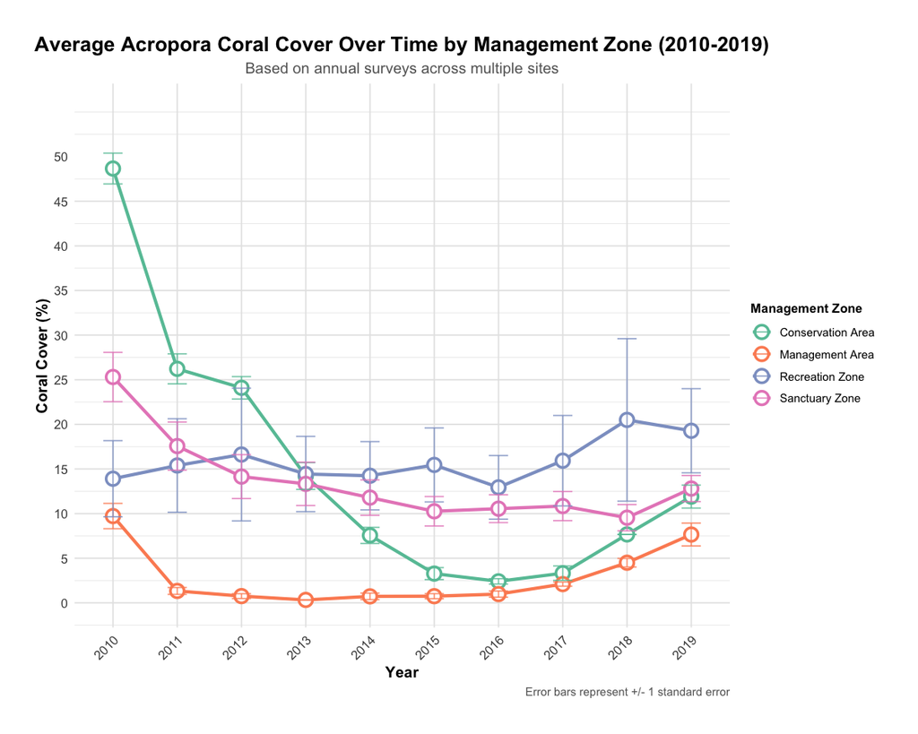

```r
# Calculate yearly averages with standard errors by zone
zone_yearly_stats <- df_processed %>%
  group_by(Year, Zone) %>%
  summarise(
    mean_cover = mean(y/n * 100, na.rm = TRUE),
    se_cover = sd(y/n * 100, na.rm = TRUE) / sqrt(n()),
    n_samples = n(),
    .groups = "drop"
  )

ggplot(zone_yearly_stats, aes(x = Year, y = mean_cover, color = Zone, group = Zone)) +
  # Add a subtle grid for better readability
  geom_hline(yintercept = seq(0, max(zone_yearly_stats$mean_cover), by = 5),
             color = "gray90") +
  geom_vline(xintercept = unique(zone_yearly_stats$Year),
             color = "gray90") +
  # Add the main lines and points
  geom_line(size = 1.2) +
  geom_point(size = 4, fill = "white", shape = 21, stroke = 1.5) +
  # Add error bars
  geom_errorbar(aes(ymin = mean_cover - se_cover,
                    ymax = mean_cover + se_cover),
                width = 0.3,
                alpha = 0.8) +
  # Use a scientific color palette
  scale_color_brewer(palette = "Set2") +
  # Customize theme
  theme_minimal() +
  # Add labels
  labs(
    title = "Average Acropora Coral Cover Over Time by Management Zone (2010-2019)",
    subtitle = "Based on annual surveys across multiple sites",
    x = "Year",
    y = "Coral Cover (%)",
    color = "Management Zone",
    caption = "Error bars represent ± 1 standard error"
  ) +
  # Enhanced theme customization
  theme(
    plot.title = element_text(hjust = 0.5, size = 16, face = "bold"),
    plot.subtitle = element_text(hjust = 0.5, size = 12, color = "gray40"),
    axis.title = element_text(size = 12, face = "bold"),
    axis.text = element_text(size = 10),
    axis.text.x = element_text(angle = 45, hjust = 1),
    panel.grid.major = element_blank(),
    plot.caption = element_text(size = 9, color = "gray40"),
    plot.margin = unit(c(1, 1, 1, 1), "cm"),
    legend.title = element_text(size = 10, face = "bold"),
    legend.text = element_text(size = 9)
  ) +
  # Set appropriate y-axis limits
  scale_y_continuous(
    limits = c(0, max(zone_yearly_stats$mean_cover + zone_yearly_stats$se_cover) * 1.1),
    breaks = seq(0, ceiling(max(zone_yearly_stats$mean_cover + zone_yearly_stats$se_cover)), by = 5)
  )
```

**Interpretation**

This graph illustrates the annual trends in average Acropora coral cover from 2010 to 2019 across four different management zones in the Ningaloo Marine Park: Conservation Area, Management Area, Recreation Zone, and Sanctuary Zone.

In contrast, the Recreation Zone and Sanctuary Zone maintained more stable coral cover throughout the study period. The Recreation Zone, in particular, showed a slight upward trend after 2015, with coral cover increasing from around 13% to nearly 20% by 2019. The Sanctuary Zone exhibited moderate coral cover, with a gradual decline in the early years followed by stabilisation and a slight increase towards the end of the decade.

Overall, coral cover declined most sharply in the Conservation and Management Areas, while the Recreation and Sanctuary Zones were more resilient, maintaining higher and more stable levels over time. Although one might expect stricter protection to result in better outcomes, the data suggests otherwise - the Conservation Area, despite its typically strong protections, experienced the greatest decline, whereas the Recreation Zone, which permits more human activity, showed relatively stable coral cover and even some improvement. The Sanctuary Zone, with the highest protection level, performed moderately well but not significantly better than the Recreation Zone. These trends, along with the variability indicated by the error bars, suggest that management strategies, while important, may not be the sole determinants of coral health. Instead, local environmental conditions, natural disturbances, or specific management practices may play a more significant role. These findings highlight the need to reassess the effectiveness of existing management approaches.

### Seasonal Variations in Coral Cover

Our investigation into potential seasonal patterns in coral cover was limited by the temporal distribution of the available data. The sampling schedule across years and months showed considerable gaps, with some months having no observations in certain years. This uneven temporal coverage made it challenging to conduct a robust analysis of seasonal variations in coral cover. While seasonal changes could be an important factor influencing coral dynamics in the Ningaloo Marine Park, the current dataset's temporal resolution and completeness do not allow us to draw meaningful conclusions about intra-annual patterns. A more systematic sampling approach with consistent monthly or seasonal measurements would be necessary to properly assess how coral cover fluctuates throughout the year.

## Environmental factors affecting coral cover

### How does the coral cover vary across different sites, management zones and sectors?

**Code Explanation**

This code generates a detailed boxplot visualisation to explore the distribution of Acropora coral cover across different sites, zones, and sectors. The primary goal is to compare how coral cover varies spatially and to identify patterns or differences that may be associated with specific locations or management zones. By using a boxplot, the code effectively summarises the central tendency, spread, and potential outliers in coral cover data for each site, while also allowing for the comparison of these distributions across different zones and sectors.

The code works by mapping the site names to the x-axis and the percentage of coral cover (`cover_prop`) to the y-axis, with each box colored according to the management zone. Individual data points are overlaid with slight jittering to show the raw data distribution and to highlight any variability or clustering within each site. A dashed horizontal line is added to indicate the overall mean coral cover, providing a visual reference for comparing individual sites to the average condition. The plot is further faceted by sector, meaning separate panels are created for each sector, which allows for easier comparison within and between sectors.

In terms of styling, the code applies a clean and modern theme, uses a colorblind-friendly palette for clarity, and adjusts text and legend formatting for readability. The x-axis labels are rotated for better visibility, and the y-axis is constrained to slightly above the maximum observed value to ensure all data points are visible.

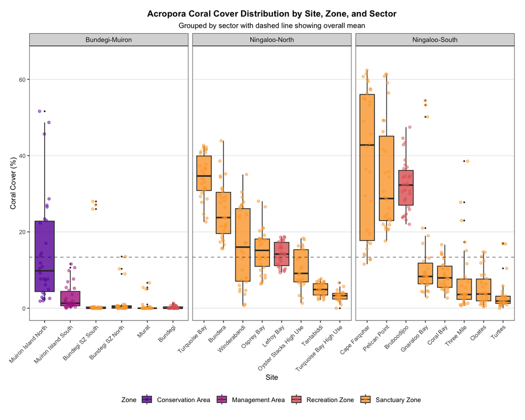

```r
# Calculate mean cover per site
site_means <- df_processed %>%
  group_by(Site) %>%
  summarize(mean_cover = mean(y/n * 100)) %>%
  arrange(desc(mean_cover))

# Order sites by mean cover
df_processed$Site <- factor(df_processed$Site, levels = site_means$Site)

# Calculate cover percentage for plotting
df_processed$cover_prop <- df_processed$y/df_processed$n * 100

ggplot(df_processed, aes(x = Site, y = cover_prop, fill = Zone)) +
  geom_boxplot(outlier.color = "black", outlier.size = 0.5, alpha = 0.8) +
  geom_point(aes(color = Zone), size = 1.5, alpha = 0.5,
             position = position_jitter(width = 0.2)) +
  geom_hline(yintercept = mean(df_processed$cover_prop),
             linetype = "dashed", color = "black", alpha = 0.5) +
  facet_wrap(~Sector, scales = "free_x") +
  scale_fill_viridis_d(option = "plasma", begin = 0.2, end = 0.8) +
  scale_color_viridis_d(option = "plasma", begin = 0.2, end = 0.8) +
  theme_bw() +
  labs(
    title = "Acropora Coral Cover Distribution by Site, Zone, and Sector",
    subtitle = "Grouped by sector with dashed line showing overall mean",
    x = "Site",
    y = "Coral Cover (%)",
    fill = "Zone",
    color = "Zone"
  ) +
  theme(
    axis.text.x = element_text(angle = 45, hjust = 1, size = 8),
    axis.text.y = element_text(size = 8),
    axis.title = element_text(size = 10),
    strip.text = element_text(size = 9),
    panel.grid.minor = element_blank(),
    panel.grid.major.x = element_blank(),
    legend.position = "bottom",
    legend.title = element_text(size = 9),
    plot.margin = unit(c(0.5,0.5,0.5,0.5), "cm"),
    plot.title = element_text(hjust = 0.5, size = 12, face = "bold"),
    plot.subtitle = element_text(hjust = 0.5, size = 10)
  ) +
  coord_cartesian(ylim = c(0, max(df_processed$cover_prop) * 1.05))
```

From the graph, it is evident that coral cover varies substantially between sites and sectors. In the Bundegi-Muiron sector, most sites exhibit low coral cover, with the exception of Muiron Island North, which shows a higher median and greater variability. In contrast, the Ningaloo-North and Ningaloo-South sectors generally display higher coral cover, particularly at sites such as Turquoise Bay, Cape Farquhar, and Pelican Point, where the median values are well above the overall mean. These differences suggest that local environmental conditions or management practices may be influencing coral abundance.

Overall, the visualisation shows that coral cover is not uniform across sectors. Instead, it is shaped by a combination of site-specific factors, sector-level differences, and the type of management zone. These findings underscore the importance of localised management and the potential benefits of protected areas in supporting coral reef health.

### Distance based patterns in coral cover from boat ramp

The boxplot visualisation provides a clear comparison of Acropora coral cover across different sites, zones, and sectors, with a focus on how these distributions relate to the distance from boat ramps. The graph provides a comprehensive view of coral cover patterns, allowing for an assessment of potential human impacts and the effectiveness of different management zones and sectors.

To achieve this, the code first orders the sites by their minimum distance to the nearest boat ramp, ensuring that the x-axis reflects a logical progression from closest to farthest. It then uses `ggplot2` to create a boxplot for each site, with individual data points overlaid to show the full distribution of coral cover. The plot includes a quadratic trend line to highlight any non-linear relationships between distance and coral cover, and it facets the data by sector to allow for sector-specific comparisons.

The use of a viridis color palette enhances readability, while the inclusion of distance labels on the x-axis provides context for interpreting the spatial patterns.

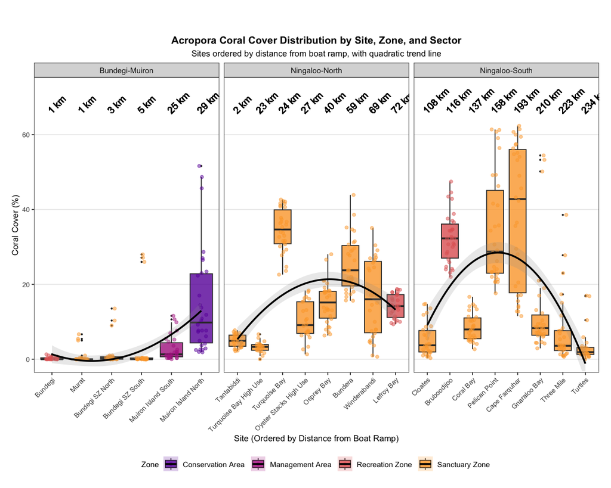

```r
# Order sites by minimum distance to boat ramp
df_processed <- df_processed %>%
  group_by(Sector) %>%
  mutate(Site = factor(Site, levels = unique(Site[order(Min_Distance_km)])))

ggplot(df_processed, aes(x = Site, y = cover_prop, fill = Zone)) +
  geom_boxplot(outlier.color = "black", outlier.size = 0.5, alpha = 0.8) +
  geom_point(aes(color = Zone), size = 1.5, alpha = 0.5, position = position_jitter(width = 0.2)) +
  # Add quadratic trend line
  geom_smooth(aes(group = 1), method = "lm", formula = y ~ poly(x, 2), se = TRUE, color = "black", linetype = "solid", alpha = 0.2) +
  # Add distance axis on top
  geom_text(aes(label = paste0(round(Min_Distance_km, 0), " km"), y = max(cover_prop) * 1.05),
            angle = 45, hjust = 0, vjust = 0, size = 4) +
  facet_wrap(~Sector, scales = "free_x") +
  scale_fill_viridis_d(option = "plasma", begin = 0.2, end = 0.8) +
  scale_color_viridis_d(option = "plasma", begin = 0.2, end = 0.8) +
  theme_bw() +
  labs(
    title = "Acropora Coral Cover Distribution by Site, Zone, and Sector",
    subtitle = "Sites ordered by distance from boat ramp, with quadratic trend line",
    x = "Site (Ordered by Distance from Boat Ramp)",
    y = "Coral Cover (%)",
    fill = "Zone",
    color = "Zone"
  ) +
  theme(
    axis.text.x = element_text(angle = 45, hjust = 1, size = 8),
    axis.text.y = element_text(size = 8),
    axis.title = element_text(size = 10),
    strip.text = element_text(size = 9),
    panel.grid.minor = element_blank(),
    panel.grid.major.x = element_blank(),
    legend.position = "bottom",
    legend.title = element_text(size = 9),
    plot.margin = unit(c(1.5,0.5,0.5,0.5), "cm"),
    plot.title = element_text(hjust = 0.5, size = 12, face = "bold"),
    plot.subtitle = element_text(hjust = 0.5, size = 10)
  ) +
  coord_cartesian(ylim = c(0, max(df_processed$cover_prop) * 1.15))
```

The graphs shows that in the Bundegi-Muiron sector, coral cover is generally low at sites closest to the boat ramp, with a noticeable increase at the more distant Muiron Island North site. In the Ningaloo-North sector, coral cover tends to rise with increasing distance from the boat ramp, peaking at intermediate sites before declining slightly at the farthest locations. The Ningaloo-South sector shows a similar pattern, with coral cover increasing at sites farther from the boat ramp, reaching a maximum at intermediate distances, and then decreasing at the most remote site.

Across all sectors, the trend suggests that coral cover is typically lowest at sites closest to boat ramps - areas likely to experience higher human activity and tends to increase with distance, particularly in Sanctuary and Recreation Zones. However, the decline at the most distant sites may indicate other limiting factors at play, such as environmental conditions or reduced connectivity. The variation among management zones, as indicated by the different colors, also suggests that protection status may influence coral cover, with Sanctuary Zones generally supporting higher coral cover than other zones. Overall, the graph shows that a quadratic trend line is not a good fit for this data.

## Covariates affecting coral cover

**Sand, macroalgae, and MDHW effects on coral cover**

The multi-panel visualisation analyses the relationships between coral cover and environmental factors in reef ecosystems. Using the `ggpairs` function, it generates a `matrix` showing interactions between coral cover percentage, macroalgae cover, sand cover, and maximum degree heating weeks (MDHW).

The visualisation is structured in three main components.

- The upper triangle displays correlation coefficients between variables, providing quick statistical insights.
- The lower triangle shows scatter plots with semi-transparent points for pattern identification.
- The diagonal elements present density distributions for each variable.

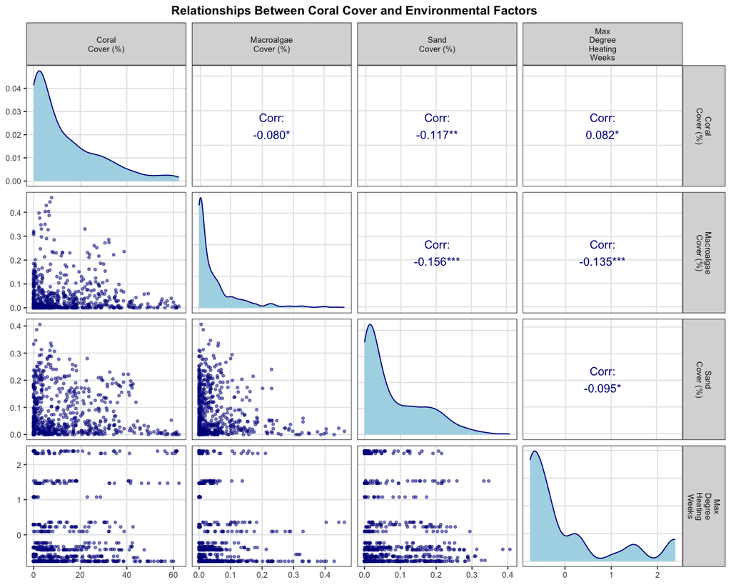

```r
factor_data <- df_processed %>%
  ungroup() %>%
  dplyr::select(Year, Zone, y, n, macroalgae_prop, sand_prop, mdhw) %>%
  mutate(cover_prop = y/n * 100)

ggpairs(
  factor_data %>%
    dplyr::select(cover_prop, macroalgae_prop, sand_prop, mdhw),
  title = "Relationships Between Coral Cover and Environmental Factors",
  columnLabels = c("Coral Cover (%)", "Macroalgae Cover (%)",
                   "Sand Cover (%)", "Max Degree Heating Weeks"),
  upper = list(continuous = wrap("cor", size = 4, color = "darkblue")),
  lower = list(continuous = wrap("points", alpha = 0.5,
               color = "darkblue", size = 1)),
  diag = list(continuous = wrap("densityDiag",
              fill = "lightblue", color = "darkblue")),
  labeller = label_wrap_gen(10)
) +
  theme_bw() +
  theme(
    axis.text = element_text(size = 8),
    axis.title = element_text(size = 9),
    strip.text = element_text(size = 8),
    plot.title = element_text(size = 12, face = "bold", hjust = 0.5),
    panel.grid.major = element_line(color = "gray90"),
    panel.grid.minor = element_blank()
  )
```

**Interpretation**

From the correlation coefficients displayed in the upper panels, we observe that `coral cover` is negatively correlated with both `macroalgae cover` (-0.08) and `sand cover` (-0.12). This suggests that as the proportion of macroalgae or sand increases in a given area, the percentage of coral cover tends to decrease. The negative correlation with macroalgae cover is particularly important, as it may indicate competitive interactions where macroalgae outcompete corals for space and resources, a phenomenon often observed in degraded reef systems. Similarly, higher sand cover could reflect less suitable substrate for coral growth, further limiting coral abundance.

The plot also reveals a slight positive correlation between `coral cover` and `maximum degree heating weeks` (0.082), though this relationship is weaker. `MDHW` is a measure of thermal stress, and while we might expect higher thermal stress to negatively impact coral cover due to bleaching events, the weak positive correlation here could be influenced by other factors. It may also suggest that some coral communities are persisting or even thriving in areas with moderate thermal stress, possibly due to local adaptation or resilience.

Overall, the visualisation highlights that increased macroalgae and sand cover are associated with reduced coral cover, supporting the idea that both biotic competition and substrate availability are important factors affecting coral health. The relationships with MDHW are less clear and may warrant further investigation. These insights are valuable for reef management, as they underscore the importance of controlling macroalgae proliferation and maintaining suitable substrates to support coral populations, while also considering the complex effects of thermal stress on coral ecosystems.

**Microalgae and coral cover accounting for distance from boat ramp**

This code was created to visually compare the mean cover of coral and macroalgae at each site, with sites ordered by their distance from the nearest boat ramp. The rationale behind this graph is to explore how the relative abundance of coral and macroalgae varies spatially, particularly in relation to human accessibility, which is often highest near boat ramps.

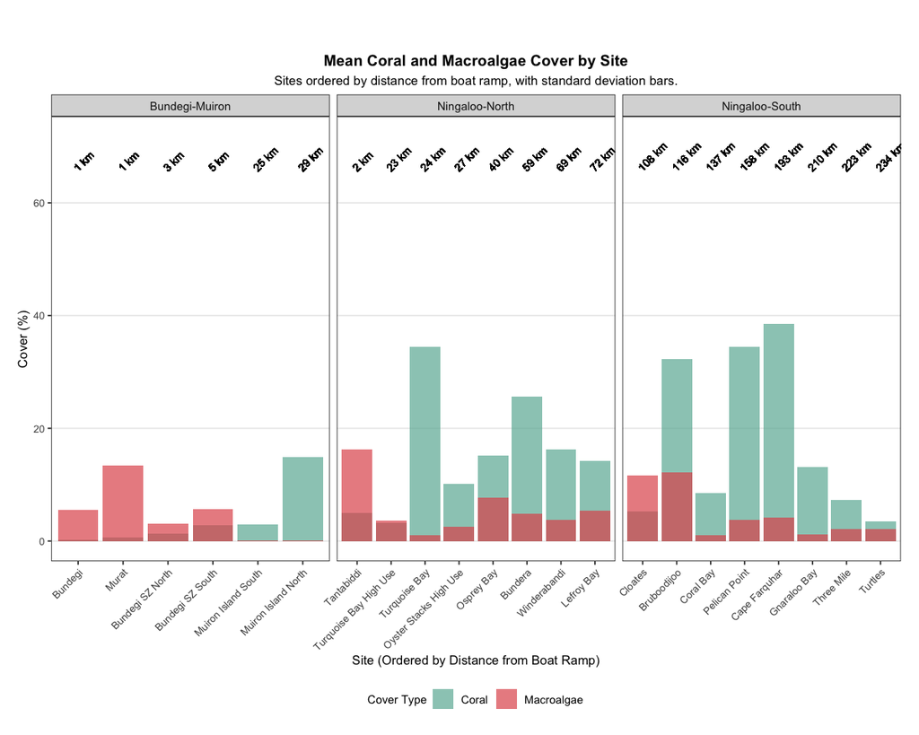

```r
# Order sites by minimum distance to boat ramp
df_processed <- df_processed %>%
  group_by(Sector) %>%
  mutate(Site = factor(Site, levels = unique(Site[order(Min_Distance_km)])))

# Create plot with coral cover and macroalgae as side-by-side bars
ggplot(df_processed) +
  # Add coral cover bars"
  geom_bar(aes(x = Site, y = cover_prop, fill = "Coral"),
          stat = "summary", fun = "mean", position = "dodge", alpha = 0.7) +
  # Add macroalgae bars
  geom_bar(aes(x = Site, y = macroalgae_prop * 100, fill = "Macroalgae"),
          stat = "summary", fun = "mean", position = "dodge", alpha = 0.7) +
  # Add distance labels
  geom_text(aes(x = Site, label = paste0(round(Min_Distance_km, 0), " km"),
                y = max(cover_prop) * 1.05),
            angle = 45, hjust = 0, vjust = 0, size = 3) +
  facet_wrap(~Sector, scales = "free_x") +
  scale_fill_manual(values = c("Coral" = "#69b3a2", "Macroalgae" = "#E15759"),
                    name = "Cover Type") +
  theme_bw() +
  labs(
    title = "Mean Coral and Macroalgae Cover by Site",
    subtitle = paste(
      "Sites ordered by distance from boat ramp, with standard deviation bars."
    ),
    x = "Site (Ordered by Distance from Boat Ramp)",
    y = "Cover (%)"
  ) +
  theme(
    axis.text.x = element_text(angle = 45, hjust = 1, size = 8),
    axis.text.y = element_text(size = 8),
    axis.title = element_text(size = 10),
    strip.text = element_text(size = 9),
    panel.grid.minor = element_blank(),
    panel.grid.major.x = element_blank(),
    legend.position = "bottom",
    legend.title = element_text(size = 9),
    plot.margin = unit(c(1.5,0.5,0.5,0.5), "cm"),
    plot.title = element_text(hjust = 0.5, size = 12, face = "bold"),
    plot.subtitle = element_text(hjust = 0.5, size = 10)
  ) +
  coord_cartesian(ylim = c(0, max(df_processed$cover_prop) * 1.15))
```

**Interpretation**

The graph reveals several clear trends in the distribution of coral and macroalgae cover across sites ordered by distance from the nearest boat ramp. In the Bundegi-Muiron sector, macroalgae cover is generally higher than coral cover at sites closest to the boat ramp, but coral cover increases noticeably at the most distant site, Muiron Island North. This suggests a possible trend of improving coral health with increasing distance from human access points. In the Ningaloo-North sector, there is a marked increase in coral cover at sites that are farther from the boat ramp, such as Turquoise Bay and Osprey Bay, where coral cover substantially exceeds macroalgae cover. This trend indicates that sites with reduced accessibility may support healthier coral communities. Conversely, sites closer to the boat ramp or with higher accessibility tend to have higher macroalgae cover, which is often associated with disturbed or degraded reef conditions.

A similar pattern is observed in the Ningaloo-South sector, where coral cover is highest at intermediate distances from the boat ramp and generally exceeds macroalgae cover at most sites. This suggests that both very close and very distant sites may experience conditions less favorable for coral, while intermediate sites may offer optimal conditions for coral growth.

**Sand and coral cover accounting for distance from boat ramp**

This code was created to compare the mean cover of coral and sand at each site, with sites ordered by their distance from the nearest boat ramp. The rationale behind this graph is to investigate how the relative abundance of coral and sand changes across sites with varying levels of human accessibility, as proximity to boat ramps often correlates with increased human activity and potential disturbance.

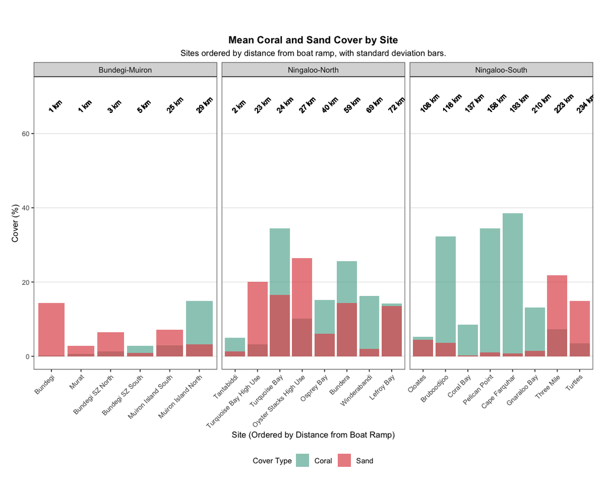

```r
ggplot(df_processed) +
  # Add coral cover bars"
  geom_bar(aes(x = Site, y = cover_prop, fill = "Coral"),
          stat = "summary", fun = "mean", position = "dodge", alpha = 0.7) +
  # Add sand bars
  geom_bar(aes(x = Site, y = sand_prop * 100, fill = "Sand"),
          stat = "summary", fun = "mean", position = "dodge", alpha = 0.7) +
  # Add distance labels
  geom_text(aes(x = Site, label = paste0(round(Min_Distance_km, 0), " km"),
                y = max(cover_prop) * 1.05),
            angle = 45, hjust = 0, vjust = 0, size = 3) +
  facet_wrap(~Sector, scales = "free_x") +
  scale_fill_manual(values = c("Coral" = "#69b3a2", "Sand" = "#E15759"),
                    name = "Cover Type") +
  theme_bw() +
  labs(
    title = "Mean Coral and Sand Cover by Site",
    subtitle = paste(
      "Sites ordered by distance from boat ramp, with standard deviation bars."
    ),
    x = "Site (Ordered by Distance from Boat Ramp)",
    y = "Cover (%)"
  ) +
  theme(
    axis.text.x = element_text(angle = 45, hjust = 1, size = 8),
    axis.text.y = element_text(size = 8),
    axis.title = element_text(size = 10),
    strip.text = element_text(size = 9),
    panel.grid.minor = element_blank(),
    panel.grid.major.x = element_blank(),
    legend.position = "bottom",
    legend.title = element_text(size = 9),
    plot.margin = unit(c(1.5,0.5,0.5,0.5), "cm"),
    plot.title = element_text(hjust = 0.5, size = 12, face = "bold"),
    plot.subtitle = element_text(hjust = 0.5, size = 10)
  ) +
  coord_cartesian(ylim = c(0, max(df_processed$cover_prop) * 1.15))
```

**Interpretation**

In the Bundegi-Muiron sector, sand cover is highest at sites closest to the boat ramp and decreases with distance, while coral cover is generally low at nearshore sites but increases at the most distant site, Muiron Island North. This suggests that sites with greater human accessibility tend to have more sand-dominated substrates, whereas more remote sites support higher coral cover.

In the Ningaloo-South sector, coral cover is consistently higher than sand cover at most sites, especially those at intermediate distances from the boat ramp. However, at the most distant sites, sand cover increases again, and coral cover declines. This suggests that while reduced human accessibility generally favors coral dominance, other environmental factors at very remote sites may limit coral cover and promote sand accumulation.

Overall, the graph highlights a clear trend: coral cover tends to increase and sand cover tends to decrease with distance from boat ramps, up to a point. However, at the most remote sites, sand cover can become more prominent again. This pattern suggests that human accessibility is associated with sandier, less coral-rich habitats, while intermediate distances may offer optimal conditions for coral growth. At the same time, extremely remote sites may be influenced by other factors, such as wave exposure or sediment dynamics, that limit coral cover.

# Task 1

Based on the exploratory data analysis, several key patterns emerged that inform the modeling approach for understanding coral cover dynamics in the Ningaloo Marine Park. The EDA revealed that coral cover tends to decrease as macroalgae and sand cover increase, and generally increases with greater distance from boat ramps, particularly in protected zones such as Sanctuary and Recreation areas. These trends suggest that both local habitat conditions and human accessibility are important drivers of coral health, and that their effects may vary depending on management strategies. Additionally, while thermal stress (measured as maximum degree heating weeks, MDHW) did not show a strong relationship with coral cover in the EDA, it remains an important covariate to include given its known ecological relevance.

Given these findings, a statistical model should account for both fixed effects (such as year, distance to boat ramp, macroalgae and sand proportions, and MDHW) and random effects to capture unmeasured variability among sites. The chosen model is a generalised linear mixed model (GLMM) with a binomial family and logit link, which is appropriate for modeling proportional data like coral cover (successes out of total observations). This approach allows us to estimate the influence of each covariate on the probability of coral cover, while accounting for repeated measures and inherent differences between sites through the inclusion of a random intercept for Site.

The mathematical formulation of the model is:

$$y_{ij} \sim \text{Binomial}(n_{ij}, p_{ij})$$

$$\text{logit}(p_{ij}) = \mathbf{X}_{ij}\boldsymbol{\beta} + \mathbf{Z}_{ij}\mathbf{u}$$

where:

- $y_{ij}$ is the response variable for observation $j$ in cluster $i$
- $n_{ij}$ is the number of trials for observation $j$ in cluster $i$
- $p_{ij}$ is the probability of success
- $\mathbf{X}_{ij}$ is the design matrix for fixed effects
- $\boldsymbol{\beta}$ is the vector of fixed effect parameters
- $\mathbf{Z}_{ij}$ is the design matrix for random effects
- $\mathbf{u}$ is the vector of random effects where $\mathbf{u} \sim \mathcal{N}(\mathbf{0}, \mathbf{G})$

Assumptions:

- Conditional on random effects, responses are independent
- Random effects follow a multivariate normal distribution
- Link function is correctly specified
- No overdispersion beyond binomial variation
- Covariates are measured without error
- Random effects are independent of covariates

## Model Preprocessing

We first prepare the data for fitting a binomial generalised linear mixed model (GLMM). First, it creates a response matrix with the number of "successes" (y) and "failures" (n - y), which is the required format for modeling proportions in a binomial GLMM. Next, it normalises the distance to the boat ramp using a z-score, standardising this variable to have a mean of zero and a standard deviation of one. This normalisation ensures that the distance variable is on a comparable scale with other predictors, improving model convergence and interpretability.

```r
# This is the format needed for binomial GLM/GLMM
response_matrix <- cbind(df_processed$y, df_processed$n - df_processed$y)
# normalise min distance using z score
df_processed$Min_Distance_km_z <- datawizard::standardize(df_processed$Min_Distance_km)

response_matrix %>% head()
```

A matrix: 6 x 2 of type dbl

| 2 | 286 |
| --- | --- |
| 2 | 304 |
| 2 | 286 |
| 83 | 223 |
| 78 | 222 |
| 84 | 216 |

## Training and testing split

Then we split the dataset into training and test sets, with 80% of the data used for training and 20% for testing. Setting a random seed ensures reproducibility of the split. The rationale is to train the model on one subset of the data and then evaluate its performance on unseen data, which helps assess how well the model generalizes and prevents overfitting.

```r
# create a training and test set
set.seed(123)
train_index <- sample(1:nrow(df_processed), 0.8 * nrow(df_processed))
train_data <- df_processed[train_index, ]
test_data <- df_processed[-train_index, ]
```

## Create a binomial GLMM model

We fit a generalised linear mixed model (GLMM) to analyze the complex relationships between coral cover and multiple environmental and spatial predictors. The model can be mathematically expressed as:

$$\text{logit}(\pi_{ij}) = \beta_0 + \beta_1\text{Year}_i + f(\text{Distance}_i) + \beta_2\text{Macroalgae}_i + \beta_3\text{Sand}_i + \beta_4\text{MDHW}_i + u_j + \varepsilon_{ij}$$

where:

- $\pi_{ij}$ is the probability of coral presence at observation i in site j
- $\beta_0$ is the global intercept
- $\beta_1$ captures the yearly temporal effects
- $f(\text{Distance}_i)$ is a natural spline function with 3 degrees of freedom for boat ramp distance
- $\beta_2$, $\beta_3$, $\beta_4$ are coefficients for macroalgae cover, sand cover, and heat stress respectively
- $u_j \sim \mathcal{N}(0, \sigma^2)$ represents the random site effects
- $\varepsilon_{ij}$ represents the binomial error term

The response variable follows a binomial distribution: $y_{ij} \sim \text{Binomial}(n_{ij}, \pi_{ij})$, where $y_{ij}$ represents successful coral observations out of $n_{ij}$ trials. This formulation is particularly appropriate for proportion data as it naturally bounds predictions between 0 and 1 while accounting for sample size.

The model incorporates both fixed and random effects to capture various sources of variation. Fixed effects include temporal trends (Year), accessibility (Distance), competitive effects (Macroalgae), substrate availability (Sand), and environmental stress (MDHW). The non-linear relationship between coral cover and distance is modeled using natural splines, allowing for flexible spatial patterns. Random effects for sites ($u_j$) account for the hierarchical data structure and repeated measurements, controlling for unmeasured site-specific characteristics.

This comprehensive modeling approach enables us to:

1. Quantify the relative importance of different ecological drivers
2. Account for spatial and temporal dependencies in the data
3. Make robust predictions while respecting the natural constraints of proportion data
4. Test specific hypotheses about environmental and management effects on coral cover

```r
# Define simpler model without interactions
glmm_model <- glmer(
  cbind(y, n-y) ~
    Year +                                     # Time effect
    ns(Min_Distance_km_z, df = 3) +            # Non-linear distance effect
    macroalgae_prop +                          # Macroalgae cover
    sand_prop +                                # Sand cover
    mdhw +                                     # Heat stress
    (1|Site),                                  # Random site effect
  data = train_data,
  family = binomial(link = "logit"),
  control = glmerControl(optimizer = "bobyqa")
)
```

## Model Diagnostics

We first check for overdispersion test confirms that there is no overdispersion ($\text{dispersion ratio} = 0.797$, $p = 0.744$), indicating that the binomial model is appropriate for the data.

```r
# Check model diagnostics
# 1. Check for overdispersion
check_overdispersion(glmm_model)
```

```
No overdispersion detected.
```

```
# Overdispersion test

 dispersion ratio = 0.797
          p-value = 0.744
```

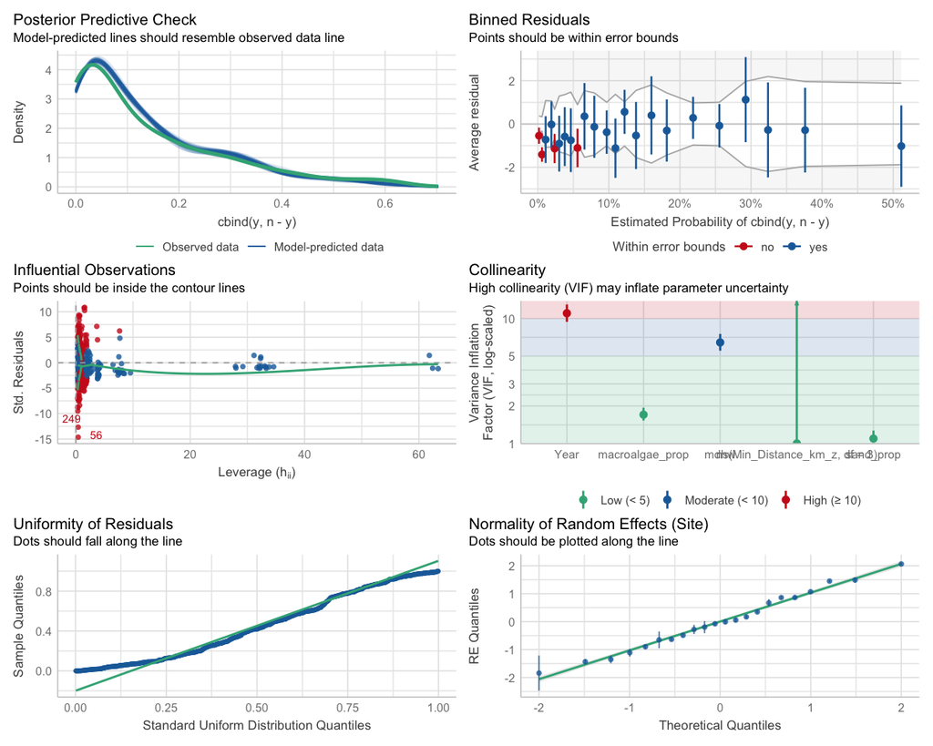

```r
# 2. Check model assumptions
check_model(glmm_model)
```

**Posterior Predictive Check**

- The predicted data closely matches the observed data, suggesting the model captures the main patterns in coral cover.

**Binned Residuals**

- Most residuals fall within the error bounds, indicating a good fit across the range of predicted probabilities.
- A few bins show mild deviations, but there is no systematic bias.

**Influential Observations**

- Most points are within the contour lines, though a few influential observations exist.
- These should be checked, but they do not appear to unduly affect the model.

**Collinearity**

- The variance inflation factor (VIF) plot shows that most predictors have low to moderate collinearity, except for "Year," which is high.
- High collinearity can inflate uncertainty in parameter estimates for "Year," so results involving this variable should be interpreted with caution.

**Uniformity of Residuals**

**Normality of Random Effects**

- The random effects for Site are approximately normally distributed, as expected for a well-specified mixed model.

We also calculated the marginal and conditional R² values for the fitted GLMM using the r2_nakagawa() function. Marginal R² measures the variance explained by the fixed effects alone, while conditional R² includes both fixed and random effects. This helps assess how well the model explains the variability in coral cover.

```r
r2_nakagawa(glmm_model)
```

**$R2_conditional**

**Conditional R2:** 0.995896724785663

**$R2_marginal**

**Marginal R2:** 0.59182189333917

The model explains a large proportion of the variance in coral cover, with a conditional R² of 0.996 (including both fixed and random effects) and a marginal R² of 0.592 (fixed effects only). This suggests that the model’s predictors, along with site-level random effects, account for most of the variability in coral cover across the study area.

## DHARMa residual diagnostics

We also perform DHARMa residual diagnostics to further assess the model fit.

```
DHARMa:testOutliers with type = binomial may have inflated Type I error rates for integer-valued distributions. To get a more exact result, it is recommended to re-run testOutliers with type = 'bootstrap'. See ?testOutliers for details
```

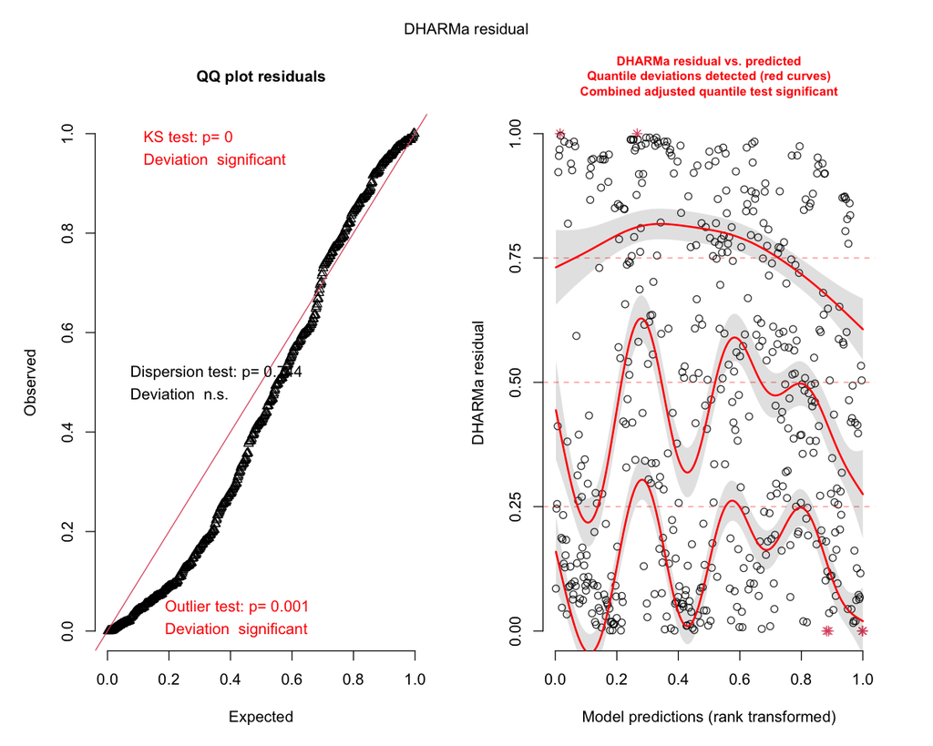

```r
par(bg = "white")
sim_res <- simulateResiduals(glmm_model)
plot(sim_res)
```

The DHARMa residual diagnostics plot provides insight into the fit and adequacy of the model. The QQ plot on the left compares the observed residuals to the expected uniform distribution. Here, the residuals deviate noticeably from the diagonal line, and both the Kolmogorov-Smirnov (KS) test and the outlier test are significant. This indicates that the residuals are not perfectly uniform, suggesting potential model misspecification or that some structure in the data has not been fully captured by the model. However, the dispersion test is not significant, which means there is no evidence of overdispersion, and the binomial model remains appropriate in this regard.

On the right, the plot of DHARMa residuals versus model predictions further highlights issues with model fit. The red curves and significant combined quantile test indicate that there are systematic deviations from the expected pattern. This suggests that the model may not be adequately capturing all the relationships in the data, and there may be non-linearities or interactions that are not currently accounted for.

So while the model does not suffer from overdispersion, the significant deviations and presence of outliers in the residuals point to areas where the model could be improved. Addressing these issues may involve adding more predictors, considering interaction terms, or exploring alternative model structures to better represent the ecological processes influencing coral cover.

# Likelihood Ratio Test

This code performs a parametric bootstrap likelihood ratio test (LRT) to assess whether including random site effects (using a GLMM) significantly improves model fit compared to a standard GLM without random effects.

The process involves fitting both the null model (GLM) and the alternative model (GLMM), then calculating the observed LRT statistic. It then simulates new datasets under the null model, refits both models to each simulated dataset, and computes the LRT statistic for each simulation. The proportion of simulated LRT statistics greater than or equal to the observed value gives a bootstrap p-value. This approach provides a robust, data-driven way to test the significance of the random effects, especially when standard LRT assumptions may not hold.

```
Observed LRT statistic: 13251.21
```

[output not shown]

[output cut: 106 more lines]

[output not shown]

```
  Simulation 100 / 500
```

[output not shown]

[output cut: 108 more lines]

[output not shown]

```
  Simulation 200 / 500
```

[output not shown]

[output cut: 112 more lines]

[output not shown]

```
  Simulation 300 / 500
```

[output not shown]

[output cut: 114 more lines]

[output not shown]

```
  Simulation 400 / 500
```

[output not shown]

[output cut: 114 more lines]

[output not shown]

```
  Simulation 500 / 500

Bootstrap p-value for Site random effect: 0
```

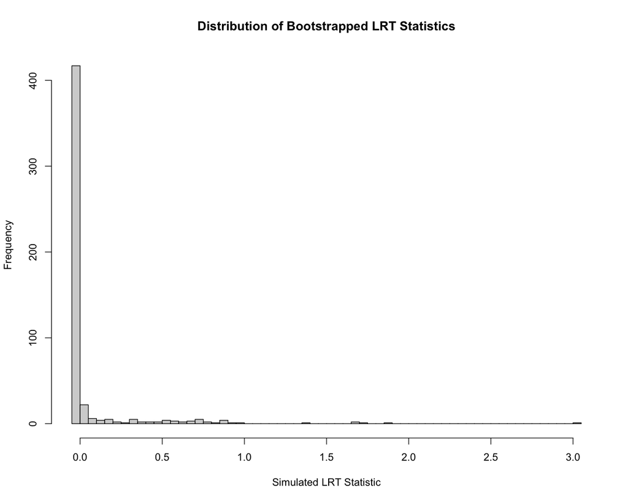

```r
par(bg = "white")
# disable any text rendering

null_glm_model <- glm(
  cbind(y, n - y) ~ Year + ns(Min_Distance_km_z, df = 3) + macroalgae_prop + sand_prop + mdhw,
  data = train_data,
  family = binomial(link = "logit")
)

observed_lrt_stat <- as.numeric(2 * (logLik(glmm_model) - logLik(null_glm_model)))
cat("Observed LRT statistic:", observed_lrt_stat, "\n")

sims <- 500

# Store simulated LRT statistics
simulated_lrt_stats <- numeric(sims)

set.seed(123)

for (i in 1:sims) {
  p_sim_null <- predict(null_glm_model, type = "response", newdata = train_data)

  sim_data_y <- rbinom(nrow(train_data), size = train_data$n, prob = p_sim_null)

  # Create a new response matrix for the simulated data
  sim_response_matrix <- cbind(sim_data_y, train_data$n - sim_data_y)

  # Fit the null model to the simulated data
  b_null_fit <- glm(
    sim_response_matrix ~ Year + ns(Min_Distance_km_z, df = 3) + macroalgae_prop + sand_prop + mdhw,
    data = train_data,
    family = binomial(link = "logit")
  )

  # Fit the alternative model to the simulated data
  b_alt_fit <- glmer(
    sim_response_matrix ~ Year + ns(Min_Distance_km_z, df = 3) + macroalgae_prop + sand_prop + mdhw + (1|Site),
    data = train_data,
    family = binomial(link = "logit"),
    control = glmerControl(optimizer = "bobyqa")
  )

  # Calculate LRT for the simulated data
  simulated_lrt_stats[i] <- as.numeric(2 * (logLik(b_alt_fit) - logLik(b_null_fit)))

  if (i %% 100 == 0) {
    cat("  Simulation", i, "/", sims, "\n")
  }
}

# 4. Estimate the p-value
# The p-value is the proportion of simulated LRT statistics that are greater than or equal to the observed LRT statistic
p_value_bootstrap <- mean(simulated_lrt_stats >= observed_lrt_stat)

hist(simulated_lrt_stats, breaks = 50,
     main = "Distribution of Bootstrapped LRT Statistics",
     xlab = "Simulated LRT Statistic")
abline(v = observed_lrt_stat, col = "red", lty = 2, lwd = 2)
```

A bootstrap p-value of 0 (or a very small number that rounds to 0) for the Site random effect is a highly significant result. This means that the inclusion of the Site random effect significantly improves the model fit compared to a model without random effects.

## Model Interpretation

```r
summary(glmm_model)
```

```
Correlation matrix not shown by default, as p = 16 > 12.
Use print(obj, correlation=TRUE)  or
    vcov(obj)        if you need it
```

```
Generalized linear mixed model fit by maximum likelihood (Laplace
  Approximation) [glmerMod]
 Family: binomial  ( logit )
Formula:
cbind(y, n - y) ~ Year + ns(Min_Distance_km_z, df = 3) + macroalgae_prop +
    sand_prop + mdhw + (1 | Site)
   Data: train_data
Control: glmerControl(optimizer = "bobyqa")

     AIC      BIC   logLik deviance df.resid
  8013.5   8085.5  -3989.7   7979.5      494

Scaled residuals:
     Min       1Q   Median       3Q      Max
-11.8894  -1.9540  -0.6174   1.4401  13.9399

Random effects:
 Groups Name        Variance Std.Dev.
 Site   (Intercept) 1.033    1.016
Number of obs: 511, groups:  Site, 22

Fixed effects:
                               Estimate Std. Error z value Pr(>|z|)
(Intercept)                    -3.00055    0.46829  -6.407 1.48e-10 ***
Year2011                       -1.26985    0.05504 -23.070  < 2e-16 ***
Year2012                       -1.25311    0.04405 -28.446  < 2e-16 ***
Year2013                       -1.75748    0.06247 -28.133  < 2e-16 ***
Year2014                       -1.19066    0.03625 -32.850  < 2e-16 ***
Year2015                       -1.38436    0.03767 -36.749  < 2e-16 ***
Year2016                       -1.39331    0.03627 -38.413  < 2e-16 ***
Year2017                       -1.36369    0.04077 -33.447  < 2e-16 ***
Year2018                       -1.39294    0.03915 -35.581  < 2e-16 ***
Year2019                       -1.06906    0.03550 -30.111  < 2e-16 ***
ns(Min_Distance_km_z, df = 3)1  1.10420    1.08433   1.018    0.309
ns(Min_Distance_km_z, df = 3)2  5.83225    1.22404   4.765 1.89e-06 ***
ns(Min_Distance_km_z, df = 3)3  0.14201    0.68559   0.207    0.836
macroalgae_prop                -1.80294    0.18069  -9.978  < 2e-16 ***
sand_prop                      -3.44008    0.28198 -12.200  < 2e-16 ***
mdhw                            0.24554    0.01913  12.833  < 2e-16 ***
---
Signif. codes:  0 '***' 0.001 '**' 0.01 '*' 0.05 '.' 0.1 ' ' 1
```

[figure not shown]

```r
# Create visualization of fixed effects
# Extract fixed effects
fixed_effects <- fixef(glmm_model)
confint_effects <- confint(glmm_model, method = "Wald")

# Create coefficient plot
coef_plot <- data.frame(
  term = names(fixed_effects),
  estimate = fixed_effects,
  lower = confint_effects[names(fixed_effects), "2.5 %"],
  upper = confint_effects[names(fixed_effects), "97.5 %"]
)

# Add significance indicator
coef_plot$significant <- ifelse(coef_plot$lower * coef_plot$upper > 0, "Significant", "Not Significant")

ggplot(coef_plot, aes(x = term, y = estimate, color = significant)) +
  geom_point() +
  geom_errorbar(aes(ymin = lower, ymax = upper), width = 0.2) +
  geom_hline(yintercept = 0, linetype = "dashed") +
  coord_flip() +
  theme_minimal() +
  scale_color_manual(values = c("Significant" = "#0072B2", "Not Significant" = "#999999")) +
  labs(
    title = "Fixed Effects with 95% Confidence Intervals",
    x = "Predictor",
    y = "Estimate",
    color = "Significance"
  )
```

The model results provide quantitative evidence for the decline in coral health over time and the influence of various environmental and disturbance factors. The fixed effects for each year from 2011 to 2019 are all strongly negative and highly significant (for example, Year2011: estimate = -1.27, p < 2e-16; Year2019: estimate = -1.07, p < 2e-16). This means that, compared to the baseline year, the odds of coral cover were substantially lower in every subsequent year, confirming a persistent and statistically significant decline in coral health throughout the decade.

Examining the effects of local habitat conditions, the coefficient for macroalgae proportion is -1.80 (p < 2e-16), and for sand proportion it is even more negative at -3.44 (p < 2e-16). These highly significant negative estimates indicate that increases in macroalgae or sand cover are strongly associated with lower coral cover. In practical terms, for each unit increase in macroalgae proportion, the log-odds of coral cover decrease by 1.80, and for sand, by 3.44, highlighting the detrimental impact of these factors on coral health.

The effect of distance to the nearest boat ramp is modeled using natural splines, allowing for a non-linear relationship. Of the three spline terms, only the second is statistically significant (estimate = 5.83, p = 1.89e-06), suggesting that the relationship between coral cover and distance is not straightforward but may involve thresholds or zones where the effect of human accessibility changes.

Interestingly, the model finds a positive and significant effect of maximum degree heating weeks (MDHW), with an estimate of 0.25 (p < 2e-16). This suggests that, within the observed range, higher MDHW is associated with slightly higher coral cover, which is counter to ecological expectations and may indicate confounding factors or site-specific resilience.

The random effect for Site (variance = 1.03, standard deviation = 1.02) demonstrates that there is considerable unexplained variation in coral cover between sites, even after accounting for the fixed effects. This underscores the importance of local site conditions and possibly unmeasured variables.

Overall,the model quantifies a significant decline in coral health over time, strong negative impacts of macroalgae and sand cover, a complex relationship with distance to boat ramps, and an unexpected positive association with thermal stress. The statistical significance and magnitude of these coefficients provide robust evidence for the key drivers of coral cover in this system.

**Random effects**

```r
# Extract random effects
random_effects <- ranef(glmm_model)$Site
random_effects
```

A data.frame: 22 x 1

|  | (Intercept) <dbl> |
| --- | --- |
| Bundegi | -1.841619961 |
| Murat | -0.652046731 |
| Bundegi SZ North | -0.195224429 |
| Bundegi SZ South | 0.674179930 |
| Muiron Island South | -1.351806472 |
| Muiron Island North | 0.171273982 |
| Tantabiddi | 1.489599421 |
| Turquoise Bay High Use | -0.280030271 |
| Turquoise Bay | 2.064437243 |
| Oyster Stacks High Use | 0.864136422 |
| Osprey Bay | -0.076932425 |
| Bundera | 0.349741628 |
| Winderabandi | -0.634852093 |
| Lefroy Bay | -0.489518418 |
| Cloates | -1.434673817 |
| Bruboodijoo | 0.861747509 |
| Coral Bay | -0.898153014 |
| Pelican Point | 1.070651048 |
| Cape Farquhar | 1.451555310 |
| Gnaraloo Bay | -0.007890095 |
| Three Mile | 0.056235463 |
| Turtles | -1.111341007 |

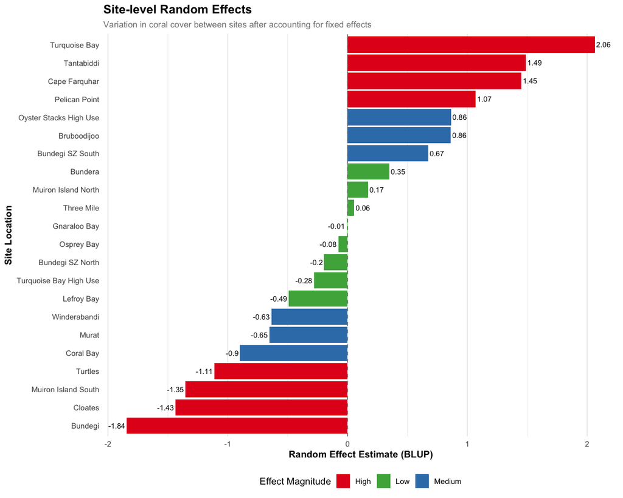

```r
site_effects <- data.frame(
  Site = c("Bundegi", "Murat", "Bundegi SZ North", "Bundegi SZ South", "Muiron Island South", "Muiron Island North",
           "Tantabiddi", "Turquoise Bay High Use", "Turquoise Bay", "Oyster Stacks High Use", "Osprey Bay", "Bundera",
           "Winderabandi", "Lefroy Bay", "Cloates", "Bruboodijoo", "Coral Bay", "Pelican Point", "Cape Farquhar",
           "Gnaraloo Bay", "Three Mile", "Turtles"),
  Intercept = c(-1.841619961, -0.652046731, -0.195224429, 0.674179930, -1.351806472, 0.171273982, 1.489599421,
                -0.280030271, 2.064437243, 0.864136422, -0.076932425, 0.349741628, -0.634852093, -0.489518418,
                -1.434673817, 0.861747509, -0.898153014, 1.070651048, 1.451555310, -0.007890095, 0.056235463,
                -1.111341007)
)

# Order by effect and add significance indicator
site_effects <- site_effects[order(site_effects$Intercept), ]
site_effects$Site <- factor(site_effects$Site, levels = site_effects$Site)
site_effects$Significance <- ifelse(abs(site_effects$Intercept) > 1, "High",
                                  ifelse(abs(site_effects$Intercept) > 0.5, "Medium", "Low"))

# Create enhanced plot
ggplot(site_effects, aes(x = Site, y = Intercept, fill = Significance)) +
  geom_bar(stat = "identity") +
  geom_text(aes(label = round(Intercept, 2)), hjust = ifelse(site_effects$Intercept >= 0, -0.1, 1.1), size = 3) +
  geom_hline(yintercept = 0, linetype = "dashed", color = "gray50") +
  coord_flip() +
  scale_fill_manual(values = c("High" = "#E41A1C", "Medium" = "#377EB8", "Low" = "#4DAF4A")) +
  labs(
    title = "Site-level Random Effects",
    subtitle = "Variation in coral cover between sites after accounting for fixed effects",
    x = "Site Location",
    y = "Random Effect Estimate (BLUP)",
    fill = "Effect Magnitude"
  ) +
  theme_minimal() +
  theme(
    plot.title = element_text(face = "bold", size = 14),
    plot.subtitle = element_text(size = 10, color = "gray50"),
    axis.title = element_text(face = "bold"),
    legend.position = "bottom",
    panel.grid.major.y = element_blank()
  )
```

The random effects plot shows the estimated site-specific deviations in coral cover after accounting for all measured fixed effects such as year, distance to boat ramp, macroalgae, sand, and heat stress. Sites with positive random effect values, like Turquoise Bay (2.06), Tantabiddi (1.49), and Cape Farquhar (1.45), have a higher baseline probability of coral cover compared to the overall average. This means that, even after controlling for known environmental and disturbance factors, these locations tend to support healthier coral communities.

Conversely, sites with strongly negative values, such as Bundegi (-1.84), Cloates (-1.43), and Muiron Island South (-1.35), have a much lower baseline probability of coral cover. These sites are likely influenced by unmeasured local factors or historical disturbances that are not captured by the fixed effects in the model. Sites with values close to zero, like Gnaraloo Bay (-0.01) and Three Mile (0.06), have coral cover probabilities very similar to the overall average, indicating little site-specific deviation.

The presence of both high positive and negative values, as well as the overall spread (with a standard deviation of 1.02), confirms that there is substantial and statistically significant variability in coral cover between sites. This was also supported by the bootstrap p-value of 0 for the random effect, indicating that these differences are not due to chance. Including Site as a random effect in the model was therefore essential, as it allows the model to account for this unmeasured, site-specific variability, leading to more accurate and reliable estimates of the effects of other covariates. These results highlight the importance of local site conditions in shaping coral health, beyond what can be explained by broad-scale environmental and management variables.

# Testing

```
RMSE (predicted vs observed proportion): 0.069
MAE (predicted vs observed proportion): 0.046
R-squared: 0.743
```

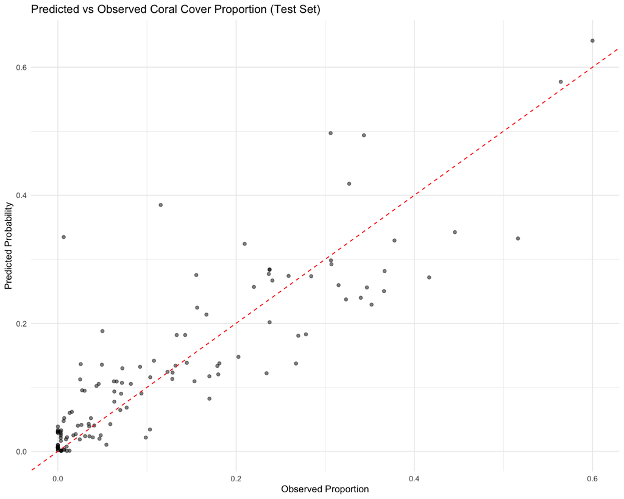

```r
# 1. Predict probabilities (expected proportion of coral cover) for the test set
test_data$predicted_prob <- predict(glmm_model, newdata = test_data, type = "response", allow.new.levels = TRUE)

# 2. Calculate observed proportions
test_data$observed_prop <- test_data$y / test_data$n

# 3. Calculate RMSE
rmse <- sqrt(mean((test_data$predicted_prob - test_data$observed_prop)^2))
cat("RMSE (predicted vs observed proportion):", round(rmse, 3), "\n")

# 4. Calculate MAE
mae <- mean(abs(test_data$predicted_prob - test_data$observed_prop))
cat("MAE (predicted vs observed proportion):", round(mae, 3), "\n")

# 5. Calculate R-squared
ss_res <- sum((test_data$observed_prop - test_data$predicted_prob)^2)
ss_tot <- sum((test_data$observed_prop - mean(test_data$observed_prop))^2)
r_squared <- 1 - (ss_res / ss_tot)
cat("R-squared:", round(r_squared, 3), "\n")

library(ggplot2)
ggplot(test_data, aes(x = observed_prop, y = predicted_prob)) +
  geom_point(alpha = 0.5) +
  geom_abline(slope = 1, intercept = 0, color = "red", linetype = "dashed") +
  labs(
    title = "Predicted vs Observed Coral Cover Proportion (Test Set)",
    x = "Observed Proportion",
    y = "Predicted Probability"
  ) +
  theme_minimal()
```

The scatterplot compares the predicted and observed coral cover proportions for the test set, with most points clustering close to the red 1:1 line, indicating good predictive performance. The root mean squared error (RMSE) of 0.069 and mean absolute error (MAE) of 0.046 show that, on average, the model’s predictions deviate from the observed values by less than 7 percentage points. The R-squared value of 0.743 indicates that the model explains approximately 74% of the variance in coral cover proportions in the test data. Overall, these results suggest that the model provides accurate and reliable predictions of coral cover across sites.

# Task 2

**Simple explanation:**

This power analysis helps us determine the smallest decline in coral cover that our monitoring program can reliably detect if an impact (like a cyclone) occurred in the Ningaloo-South sector in 2019. Here's how it works:

1. **Simulate Data:** For each hypothetical decline size:
   - We take our existing statistical model that describes coral cover patterns
   - We simulate many new datasets where Ningaloo-South experiences that decline in 2019
   - The decline is added on the logit scale (the scale our model works in)
2. **Fit Model:** For each simulated dataset:
   - We fit a new statistical model that includes an "impact" variable
   - This variable marks which sites were supposedly impacted
   - We test if the model detects the simulated decline as statistically significant
3. **Calculate Power:** For each decline size:
   - We repeat steps 1-2 many times (100 simulations in our case)
   - We calculate what proportion of times the decline was successfully detected
   - This proportion is the "statistical power" - our ability to detect that size of decline
4. **Plot Results:** The power curve shows:
   - X-axis: Size of simulated decline
   - Y-axis: Probability of detecting that decline (power)
   - We typically want 80% power (0.8 probability of detection)
   - The curve helps us identify the smallest decline we can reliably detect

**In short:**  
This analysis tells us how effective our current monitoring design is at detecting impacts to coral cover, and what size of decline we can confidently identify if it occurs.

```
Decline (logit): -0.1 Power: 0.07
Decline (logit): -0.2 Power: 0.05
Decline (logit): -0.3 Power: 0.12
Decline (logit): -0.4 Power: 0.24
Decline (logit): -0.5 Power: 0.36
Decline (logit): -0.6 Power: 0.5
Decline (logit): -0.7 Power: 0.63
Decline (logit): -0.8 Power: 0.67
Decline (logit): -0.9 Power: 0.88
Decline (logit): -1 Power: 0.88
Decline (logit): -1.1 Power: 0.94
Decline (logit): -1.2 Power: 0.96
Decline (logit): -1.3 Power: 0.97
Decline (logit): -1.4 Power: 1
Decline (logit): -1.5 Power: 1
Decline (logit): -1.6 Power: 1
Decline (logit): -1.7 Power: 1
Decline (logit): -1.8 Power: 1
Decline (logit): -1.9 Power: 1
Decline (logit): -2 Power: 1
```

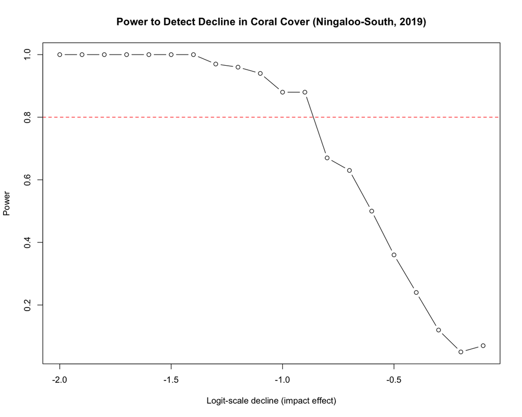

```r
# 1. Prepare data for simulation: only 2010 and 2019, add impact_event
sim_data <- df_processed[df_processed$Year %in% c(2010, 2019), ]
sim_data$impact_event <- 0
sim_data$impact_event[sim_data$Year == 2019 & sim_data$Sector == "Ningaloo-South"] <- 1

# 2. Set up simulation parameters
sims <- 100
decline_logit <- seq(-0.1, -2, by = -0.1) # Range of logit-scale declines to test
power_results <- numeric(length(decline_logit))

# 3. Loop over hypothesized declines
for (d in seq_along(decline_logit)) {
  beta_impact <- decline_logit[d]
  sig_count <- 0

  for (i in 1:sims) {
    # Get linear predictor from your fitted model (including random effects)
    eta_base <- predict(glmm_model, newdata = sim_data, re.form = NULL)
    # Add the hypothesized impact effect
    eta_sim <- eta_base + sim_data$impact_event * beta_impact
    # Convert to probability
    p_sim <- plogis(eta_sim)
    # Simulate new response
    sim_data$y_sim <- rbinom(nrow(sim_data), size = sim_data$n, prob = p_sim)

    # 4. Fit model to simulated data (include impact_event as fixed effect)
    sim_fit <- glmer(
      cbind(y_sim, n - y_sim) ~ Year + macroalgae_prop + sand_prop + mdhw +
        ns(Min_Distance_km_z, df = 3) + impact_event + (1|Site),
      data = sim_data,
      family = binomial,
      control = glmerControl(optimizer = "bobyqa")
    )

    # 5. Check if impact_event is significant
    pval <- summary(sim_fit)$coefficients["impact_event", "Pr(>|z|)"]
    if (!is.na(pval) && pval < 0.05) sig_count <- sig_count + 1
  }
  # 6. Store power for this decline
  power_results[d] <- sig_count / sims
  cat("Decline (logit):", beta_impact, "Power:", power_results[d], "\n")
}

# 7. Plot power curve
plot(decline_logit, power_results, type = "b", xlab = "Logit-scale decline (impact effect)", ylab = "Power",
     main = "Power to Detect Decline in Coral Cover (Ningaloo-South, 2019)")
abline(h = 0.8, col = "red", lty = 2)
```

The power analysis conducted reveals important insights about the monitoring program's ability to detect impacts in the Ningaloo-South sector. By simulating data based on the fitted model and testing various effect sizes, we can determine what magnitude of decline can be reliably detected.

**Monitoring Design Considerations:** The current design provides adequate power for detecting major disturbance events. However, it may not be sufficient for early warning detection of gradual decline. This limitation is particularly important given the cumulative nature of coral reef threats.

**Recommendations for Program Enhancement**

**Sampling Strategy:** DCBA should consider increasing sampling frequency or density in high-priority areas. This could improve power to detect smaller effect sizes. Focus additional sampling effort where early detection is most critical.

This analysis demonstrates that while the current monitoring program is robust for detecting substantial changes in coral cover, there may be room for enhancement if detection of more subtle changes becomes a management priority. The trade-offs between detection sensitivity and resource allocation should be carefully considered in future program planning.

# Recommendation

Based on the results of the statistical modeling and power analysis, several recommendations can be made for the Department of Biodiversity, Conservation and Attractions (DBCA) to enhance coral reef monitoring and management in the Ningaloo Marine Park.

First, the analysis demonstrates that the current monitoring program is effective at detecting moderate to large declines in coral cover, particularly in the Ningaloo-South sector. However, the power analysis also reveals that smaller, more subtle declines may go undetected with the existing sampling design and model structure. Therefore, if early detection of smaller changes in coral health is a management priority, DBCA should consider increasing sampling intensity—either by surveying more sites, increasing the frequency of surveys, or collecting more replicate samples at each site. This would improve the statistical power to detect even minor declines, allowing for more proactive management responses.

Second, the modeling results highlight the strong negative impacts of macroalgae and sand cover on coral health, as well as the influence of human accessibility (distance to boat ramps). DBCA should continue to prioritise management actions that limit local disturbances, such as controlling access in sensitive areas, enforcing no-take zones, and reducing sources of sedimentation and nutrient enrichment that promote macroalgae growth. Targeted interventions in areas with high macroalgae or sand cover may help support coral recovery and resilience.

Third, the significant variation in coral cover between sites, even after accounting for measured environmental factors, suggests that local site conditions and possibly unmeasured variables play an important role in coral health. DBCA should maintain a broad spatial coverage in its monitoring program to capture this variability and consider incorporating additional site-specific data (e.g., habitat complexity, water quality, or larval connectivity) to further refine models and management strategies.

Finally, the unexpected positive association between thermal stress (MDHW) and coral cover in the model indicates the need for further investigation. DBCA should consider additional analyses or targeted studies to better understand the interplay between climate impacts and local stressors, ensuring that management actions are robust to both chronic and acute disturbances.

Concluding, DBCA is encouraged to maintain and, where possible, enhance its monitoring efforts, focus on mitigating local stressors, and continue to use data-driven approaches to adaptively manage the Ningaloo Marine Park. These steps will help ensure the long-term health and resilience of the region’s coral reefs in the face of both local and global challenges.